# R coding - my lessons learned

Fabian Jörg Fischer

### 1. Introduction

This is an [R Markdown](http://rmarkdown.rstudio.com/) Notebook summarizing my ideas and lessons learned about programming with R, specifically in the context of forest ecology.

##### What this is:

- overview of (good) coding practices
- list of ideas/tools to solve problems

##### What this is not:

- an introduction to R
- anywhere near objective
- obligatory

Implementing coding practices takes time! Do what makes sense and is practical, don’t overwhelm yourself!

### 2. Sample data

Throughout this document, I will use Tommaso Jucker’s Tallo database as an example to work with. We will load it directly from github.

```r
# two standard libraries for my purposes
library(data.table)
library(ggplot2)

# define paths
url_tallo = "https://github.com/selva-lab-repo/TALLO/blob/main/DB/Tallo.csv.zip?raw=true"
dir_tallo = "~/Desktop/tallo_lessonslearned"
path_tallo_zipped = file.path(dir_tallo, "Tallo.csv.zip")

# create directory
if(!dir.exists(dir_tallo)) dir.create(dir_tallo)

# download file
download.file(url_tallo, destfile = path_tallo_zipped,quiet = T)

# unzip and load tallo as data.table
unzip(path_tallo, exdir = dir_tallo)
tallo = fread("~/Desktop/tallo_lessonslearned/Tallo.csv")
tallo = tallo[,5:9]
print(tallo)
```

| species | latitude | longitude | stem_diameter_cm | height_m |
| --- | --- | --- | --- | --- |
| Betula pubescens | 67.395 | 28.723 | 10.0 | 5.6 |
| Picea abies | 67.395 | 28.723 | 10.0 | 6.6 |
| Picea abies | 67.395 | 28.723 | 10.0 | 8.5 |
| Picea abies | 67.395 | 28.723 | 10.0 | 7.2 |
| Picea abies | 67.395 | 28.723 | 10.0 | 8.1 |
| Betula pubescens | 67.738 | 29.649 | 10.0 | 9.1 |
| Pinus sylvestris | 67.738 | 29.649 | 10.0 | 8.6 |
| Pinus sylvestris | 67.738 | 29.649 | 10.0 | 6.3 |
| Pinus sylvestris | 67.738 | 29.649 | 10.0 | 9.0 |
| Betula pubescens | 67.738 | 29.649 | 10.0 | 7.2 |

[output cut: 990 more lines]

[output not shown]

### 3 Syntax / Style

This section concerns coding style. It is therefore the most opinionated. The core idea is: develop your own system and stick with it.

For inspiration, you can also find so-called styleguides, e.g. google’s R styleguide: https://google.github.io/styleguide/Rguide.html

#### 3.1 Assignment in R

```r
# Which do you prefer?
tallo_species <- tallo$species
tallo_species = tallo$species
```

#### 3.2 Naming system for subsetting/aggregating

```r
# Which do you prefer for extracting a column?
tallo_species = tallo$species
tallo.species = tallo$species
talloSpecies = tallo$species # also called camelCase
```

```r
# Which do you prefer for aggregating?
height_m_max = max(tallo$height_m)
height_m.max = max(tallo$height_m)
maxheight_m = max(tallo$height_m)
```

#### 3.3 An example system

I have a couple of approximate rules for myself:

- use lower case
- use same standardized names: dbh, height, cr, cd, ca, wd, lma, sla, etc.
- use same standard units (e.g. always m, m^2, m^3)
- add simple aggregating functions at front of name
- use underscore for subsets or indicating origin
- use dot for functions or for operations on objects (some overlap with aggregating functions), but never in columns

So this would look like the following:

```r
# standardize names
colnames_tallo_new = c("species","lat","lon","dbh","height")
colnames(tallo) = colnames_tallo_new

# standardize units
# only needed for dbh
tallo$dbh = tallo$dbh * 0.01

# determine max dbh
maxdbh = max(tallo$dbh, na.rm = T)
print(maxdbh)
```

```
[1] 7.7
```

```r
maxdbh_betula = max(tallo[species %like% "Betula"]$dbh)
print(maxdbh_betula)
```

```
[1] 0.865
```

```r
# determine 95th percentile
perc95dbh = quantile(tallo$dbh, 0.95, na.rm = T)
print(perc95dbh)
```

```
  95%
0.535
```

```r
# create function to determine max dbh for a species
get.maxdbh = function(census, species_dbh = ""){
  maxdbh_species = max(census[census$species %like% species_dbh]$dbh)
  return(maxdbh_species)
}

maxdbh = get.maxdbh(census = tallo)
print(maxdbh)
```

```
[1] 7.7
```

```r
maxdbh_betula = get.maxdbh(census = tallo, species_dbh = "Betula")
print(maxdbh_betula)
```

```
[1] 0.865
```

```r
# but maybe better: add with dots at the end?
dbh.max = get.maxdbh(census = tallo)
dbh.max.rounded = round(dbh.max,2)
print(dbh.max.rounded)
```

```
[1] 7.7
```

#### 3.4 Commenting

Short answer: Yes!

Some ideas to integrate comments directly into code:

```r
cat("1. Use print messages instead of comments or use R Markdown\n") # both together do not work
```

```r
cat("2. Use easily readable names\n")
```

```r
cat("3. Use lots of functions\n")
```

```r
cat("4. Structure your code with subchapters or split it into several scripts")
```

#### 3.5 What is the tidyverse?

This is a suite of R packages developed and maintained by Hadley Wickham et al. The idea is to provide a “tidier” way of coding in R. You might have come across a number of their packages, including ggplot2, dplyr, magrittr. Note that it is an explicitly “opinionated” collection, i.e. the authors acknowledge that not everyone might agree on what “tidy” means.

My opinion on this:

- great package: ggplot2 (+ involvement of tidyverse authors in RStudio and other amazing R projects)
- be careful with the other tidyverse packages, especially when new to coding:
  - personally, I don’t think tidyverse code is easier to read
  - personally, I think tidyverse code is more difficult to debug (hidden transformations, especially in so-called pipes)
- I typically use another package called data.table: 99% of the problems I encounter in R can be easily solved with this, the other 1% need a bit thinking/research on stackoverflow.com

Cf. also: https://fromthebottomoftheheap.net/2015/06/03/my-aversion-to-pipes/

### 4. Make good use of R

R has a lot of functionalities that we sometimes only learn about late in the game.

You can:

- modify R functions from packages by looking on github, or using F2 (thanks @Beibei for tip)
- run command line programs through system()
- move files, create and delete directories through R
- source functions from a different file
- create your own package (a collection of objects/functions)

### 5. Make good use of RStudio

The same as with R. You can do lots of things in RStudio, for example you can:

- adapt the layout (wrapping text)
- create an R Markdown object: export code to html / pdf
- create an R Markdown notebook (this here): no plotting pane needed anymore
- give your scripts structure and make a table of contents (e.g. by using ‘## 1. First subsection —-’ in code)
- open multiple panes
- execute in the background via “source” (also tests your script’s functionality)
- profile your code for speed

### 6. Use ggplot2

This is a great package, make good use of it:

- multiple panes with gridExtra (grid.arrange function)
- write to file with ggsave and specify dimensions

Only a few drawbacks:

- grey background grid: use theme_bw() or even custom theme
- histograms are a bit unintuitive (stacked by default)

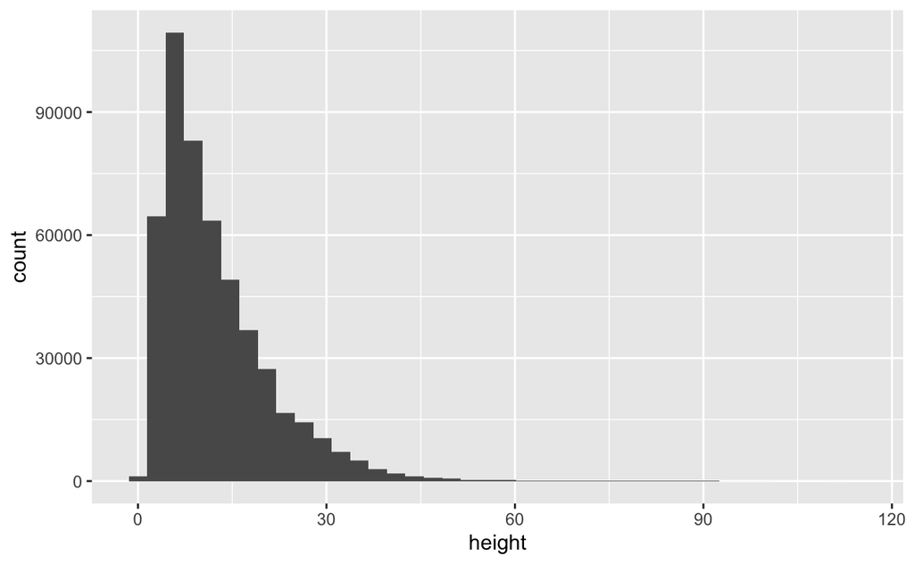

```r
# baseline histogram
ggplot(data = tallo[!is.na(height)], aes(x = height)) + geom_histogram(bins = 40)
```

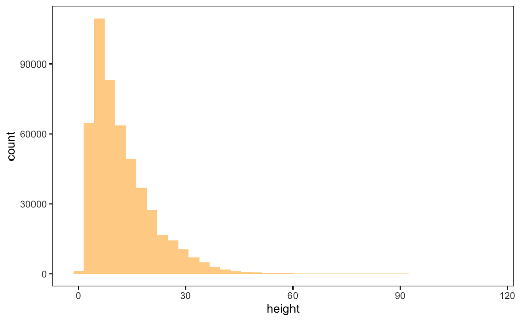

```r
# remove background and color
theme_slim = function(){theme_bw() + theme(panel.grid.major = element_blank(), panel.grid.minor = element_blank())}

ggplot(data = tallo[!is.na(height)], aes(x = height)) + geom_histogram(bins = 40, fill = "orange", alpha = 0.5) + theme_slim()
```

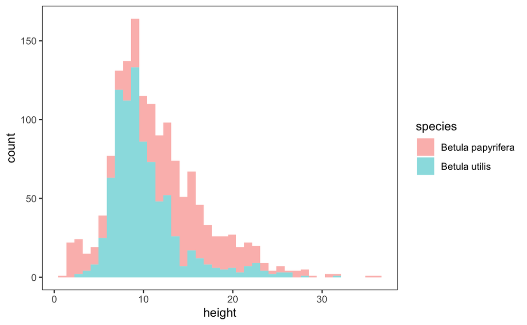

```r
# for two birch species, default stack
ggplot(data = tallo[species %in% c("Betula papyrifera","Betula utilis") & !is.na(height)], aes(height, fill = species)) + geom_histogram(bins = 40, alpha = 0.5) + theme_slim()
```

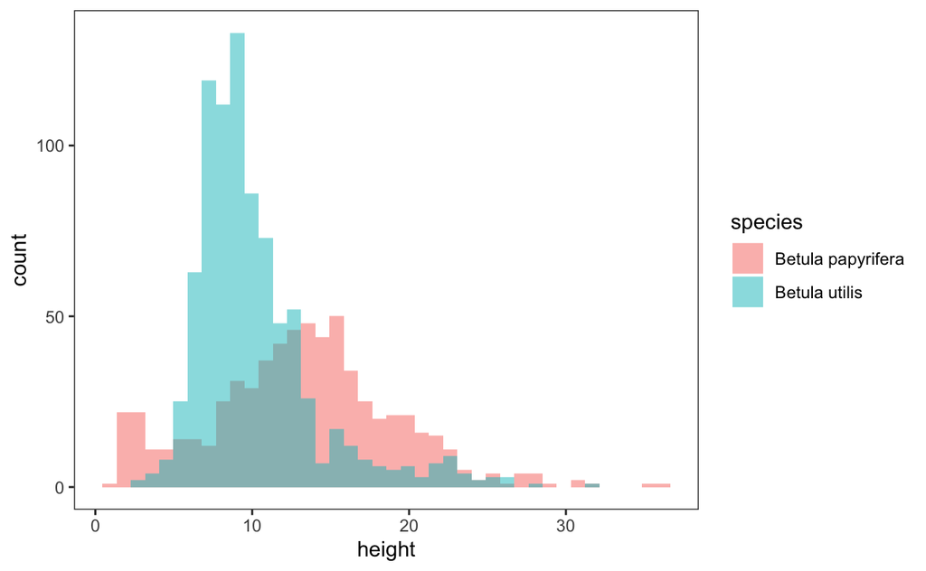

```r
# for two birch species, overlaid
ggplot(data = tallo[species %in% c("Betula papyrifera","Betula utilis") & !is.na(height)], aes(height, fill = species)) + geom_histogram(bins = 40, alpha = 0.5, position = "identity") + theme_slim()
```

### 7. Use data.table

This package provides a useful replacement of R’s default data.frame. It makes grouping / subsetting / adding new columns easy and has a lot of advanced capabilities. Most of all, it is really fast! Lots of packages, such as lidR, use it “under the hood” to speed up their own computations. It works very well with “lapply” on functions that return data.table or data.frame and “rbindlist”, plus there is also a crossover from the tidyverse.

A few examples:

```r
# Subsetting without "attaching"
tallo_betula = tallo[species %like% "Betula"]
tallo_mindbh30 = tallo[dbh >= 0.3]

# Quick grouping
tallo[species %like% "Betula",.N,species]
```

| species | N |
| --- | --- |
| Betula pubescens | 471 |
| Betula alleghaniensis | 442 |
| Betula papyrifera | 648 |
| Betula pendula | 1617 |
| Betula platyphylla | 198 |
| Betula ermanii | 19 |
| Betula maximowicziana | 22 |
| Betula lenta | 331 |
| Betula grossa | 4 |
| Betula utilis | 845 |

[output cut: 9 more lines]

[output not shown]

```r
tallo[species %like% "Betula",mean(dbh),species]
```

| species | V1 |
| --- | --- |
| Betula pubescens | 0.15095541 |
| Betula alleghaniensis | 0.21323756 |
| Betula papyrifera | 0.16114660 |
| Betula pendula | 0.17534570 |
| Betula platyphylla | 0.11821212 |
| Betula ermanii | 0.15163158 |
| Betula maximowicziana | 0.19940909 |
| Betula lenta | 0.09390030 |
| Betula grossa | 0.17900000 |
| Betula utilis | 0.18722012 |

[output cut: 9 more lines]

[output not shown]

```r
# Assignment to new columns within data.table
tallo[, nb := .N, species]
tallo[, `:=`(nb = .N, meandbh = mean(dbh)), species]
print(tallo)
```

| species | lat | lon | dbh | height | nb | meandbh |
| --- | --- | --- | --- | --- | --- | --- |
| Betula pubescens | 67.395 | 28.723 | 0.100 | 5.6 | 471 | 0.1509554 |
| Picea abies | 67.395 | 28.723 | 0.100 | 6.6 | 6723 | 0.2518434 |
| Picea abies | 67.395 | 28.723 | 0.100 | 8.5 | 6723 | 0.2518434 |
| Picea abies | 67.395 | 28.723 | 0.100 | 7.2 | 6723 | 0.2518434 |
| Picea abies | 67.395 | 28.723 | 0.100 | 8.1 | 6723 | 0.2518434 |
| Betula pubescens | 67.738 | 29.649 | 0.100 | 9.1 | 471 | 0.1509554 |
| Pinus sylvestris | 67.738 | 29.649 | 0.100 | 8.6 | 18221 | 0.2191573 |
| Pinus sylvestris | 67.738 | 29.649 | 0.100 | 6.3 | 18221 | 0.2191573 |
| Pinus sylvestris | 67.738 | 29.649 | 0.100 | 9.0 | 18221 | 0.2191573 |
| Betula pubescens | 67.738 | 29.649 | 0.100 | 7.2 | 471 | 0.1509554 |

[output cut: 990 more lines]

[output not shown]

```r
# Assignment to new data.table
tallo_betula.byspecies = tallo[species %like% "Betula",list(nb = .N, meandbh = mean(dbh), meanheight = mean(height)),by = species]
print(tallo_betula.byspecies)
```

| species | nb | meandbh | meanheight |
| --- | --- | --- | --- |
| Betula pubescens | 471 | 0.15095541 | 12.724841 |
| Betula alleghaniensis | 442 | 0.21323756 | 14.517421 |
| Betula papyrifera | 648 | 0.16114660 | 13.169444 |
| Betula pendula | 1617 | 0.17534570 | NA |
| Betula platyphylla | 198 | 0.11821212 | 11.900000 |
| Betula ermanii | 19 | 0.15163158 | 11.115789 |
| Betula maximowicziana | 22 | 0.19940909 | 21.222727 |
| Betula lenta | 331 | 0.09390030 | 9.000302 |
| Betula grossa | 4 | 0.17900000 | 18.700000 |
| Betula utilis | 845 | 0.18722012 | 10.174911 |

[output cut: 9 more lines]

[output not shown]

### 8. For loop vs. apply

Often it is said that one should not use for loops in R (because they are not vectorized), and instead use apply, lapply, sapply, mapply or inbuilt capacities (e.g. in data.table).

But for loops are quite nice, especially for complex functions:

- easy debugging (one can run for loop for one iteration or two and check each iteration)
- good progress information (by adding comments)

```r
# much much faster in this case
tallo[, ba := dbh * dbh * 0.25 * pi]

# for loop
tallo$ba_forloop = as.numeric(NA)
imax = 3000 # just first 3000
ioutput = 500 # how often to output information on progress
for(i in 1:imax){
  if(i%%ioutput == 0) cat("Iteration",i,"\n") # use modulo operator to output every 1000 iterations
  tallo[i]$ba_forloop = tallo[i]$dbh * tallo[i]$dbh * 0.25 * pi
}
```

```
Iteration 500
Iteration 1000
Iteration 1500
Iteration 2000
Iteration 2500
Iteration 3000
```

```r
# progress bar
tallo$ba_forloop = as.numeric(NA)
imax = 3000
ioutput = 500 # how often to output information on progress
nb_progressbars = imax/ioutput
for(i in 1:nb_progressbars) cat("="); cat("\n");
for(i in 1:imax){ # just first 3000
  if(i%%ioutput == 0) cat("=") # use modulo operator to output every 1000 iterations
  tallo[i]$ba_forloop = tallo[i]$dbh * tallo[i]$dbh * 0.25 * pi
}
cat("\n")
```

[output not shown]

### 9. Writing functions

A few tips:

- if possible, give objects passed on to functions the same name as the parameters within the function, this makes debugging easy
- minimize number of parameters: often a binary parameter can be subsumed into another continuous parameter (e.g. provide the size of a height threshold instead of giving an option to calculate with threshold or without)
- use tryCatch to prevent exectution stop on error

```r
divide.by = function(x, by){
  x_divided = x/by
  return(x_divided)
}

divide.by(10,2)
```

```
[1] 5
```

```r
divide.by(10,0)
```

```
[1] Inf
```

```r
divide.by(10,"zero")
```

```
Error in x/by : non-numeric argument to binary operator
```

```r
divide.by = function(x, by){
  tryCatch(
    {
      x_divided = x/by
      return(x_divided)
    },
    error = function(e){
      x_divided = as.numeric(NA)
      return(x_divided)
    }
  )
}

divide.by(10,2)
```

```
[1] 5
```

```r
divide.by(10,0)
```

```
[1] Inf
```

```r
divide.by(10,"zero")
```

```
[1] NA
```

### 10. Parallelization (advanced)

Parallelization should be last resort. Before using parallel processing for custom scripts, make sure they are well-designed and as fast as possible.

General tips where to look:

- across operating systems, you can use makeCluster(), clusterExport() and clusterEvalQ() to initialize clusters on processors on your computer. Then use parLapplyLB() for tasks with variable size (and generally slow) and parLapply() for tasks where they are all finishing in the same amount of time
- make sure to deactivate implicit parallelization and other hurdles (e.g. by setting memfrac in terra package, or threads in data.table)

### 11. General tips

Helpful details:

- use find/replace to update code (renaming, etc.)
- use %in% and %like% operators to subset and merge() to merge data.frames / data.tables: all very fast and intuitive
- be aware of different path conventions on Unix/macOS vs. Windows and use file.path() to circumvent such problems

Debugging:

- check out stackoverflow.com for your questions
- try things out on data subsets first, then scale up
- if you ever use a cluster, run a small sample first

Speed:

- check for R packages that have C/C++ functions implemented to make operations faster
- try out different versions and time them:

```r
# only works for slow functions
time_start = Sys.time()
tallo[, ba := dbh * dbh * 0.25 * pi]
time_end = Sys.time()
time_diff = time_end - time_start
print(time_diff)
```

```
Time difference of 0.008602142 secs
```

```r
# for loop
time_start = Sys.time()
tallo$ba_forloop = as.numeric(NA)
imax = 3000 # just first 3000
ioutput = 500 # how often to output information on progress
for(i in 1:imax){
  if(i%%ioutput == 0) cat("Iteration",i,"\n") # use modulo operator to output every 1000 iterations
  tallo[i]$ba_forloop = tallo[i]$dbh * tallo[i]$dbh * 0.25 * pi
}
```

```
Iteration 500
Iteration 1000
Iteration 1500
Iteration 2000
Iteration 2500
Iteration 3000
```

```r
time_end = Sys.time()
time_diff = time_end - time_start
print(time_diff)
```

```
Time difference of 33.31463 secs
```

### 12. Thank you!